# CNN_SelfPractice

```python
import tensorflow as tf
config = tf.ConfigProto()
config.gpu_options.allow_growth=True
sess = tf.Session(config=config)
```

Importing the required libraries. below we are using tensolflow

```python
# Import libraries
import os,cv2 #load and preprocess
import numpy as np #array and reshaping
import matplotlib.pyplot as plt

from sklearn.utils import shuffle
#from sklearn.cross_validation import train_test_split

from keras import backend as K
K.set_image_dim_ordering('tf') # for image ordering
#version used for keras - 2.0.8
from keras.utils import np_utils
from keras.models import Sequential
from keras.layers.core import Dense, Dropout, Activation, Flatten
from keras.layers.convolutional import Conv2D, MaxPooling2D
from keras.optimizers import SGD,RMSprop,adam
```

Below code is to get the directory path to read the folders

```python
PATH = os.getcwd()
# Define data path
train_path=PATH + '/data/train'
train_dir_list = os.listdir(train_path)

validation_path=PATH + '/data/validation'
validation_dir_list = os.listdir(validation_path)
print("number of image classes",len(train_dir_list))
```

```
('number of image classes', 21)
```

Reading the train and validation data. Below code checks for each directory in train and validation folders and reads the images. labels_list is used to collect the number of labels in train and validation, and the labels should be same in both train/validation. Used channel=1 to read the images in gray. Input is having different size images, Inorder to bring all images in one scale , I have used Open cv to resize. After that normaized the image data by changing the data type to float.

```python
img_rows=128
img_cols=128
num_channel=1
num_epoch=20

# Define the number of classes
num_classes = 21

#Loading the training data
i=-1
train_labels_list=[]
train_data_list=[]

for dataset in train_dir_list:
	img_list=os.listdir(train_path+'/'+ dataset)
	i=i+1
#	print ('Loaded the images of dataset-'+'{}\n'.format(dataset))
	for img in img_list:
		train_labels_list.append(i)
		input_img=cv2.imread(train_path + '/'+ dataset + '/'+ img )
		input_img=cv2.cvtColor(input_img, cv2.COLOR_BGR2GRAY)
		input_img_resize=cv2.resize(input_img,(128,128))
		train_data_list.append(input_img_resize)

train_data = np.array(train_data_list)
train_data = train_data.astype('float32')
train_data /= 255 #Normalization
print (train_data.shape)#(3467, 128, 128) in RGB is use (3467, 128, 128,3L)


#Loading the validation data
i=-1
validation_labels_list=[]
validation_data_list=[]

for dataset in validation_dir_list:
	img_list=os.listdir(validation_path+'/'+ dataset)
	i=i+1
#	print ('Loaded the images of dataset-'+'{}\n'.format(dataset))
	for img in img_list:
		validation_labels_list.append(i)
		input_img=cv2.imread(validation_path + '/'+ dataset + '/'+ img )
		input_img=cv2.cvtColor(input_img, cv2.COLOR_BGR2GRAY)
		input_img_resize=cv2.resize(input_img,(128,128))
		validation_data_list.append(input_img_resize)

validation_data = np.array(validation_data_list)
validation_data = validation_data.astype('float32')
validation_data /= 255
print (validation_data.shape)
```

```
(3467, 128, 128)
(367, 128, 128)
```

As the CNN input should be with axis,so extended the dimentions to shape the datasets

```python
#Reshaping for channel = 1, if we read the data as colour(RGB) image shape will be in desired format
train_data= np.expand_dims(train_data, axis=3)
print (train_data.shape)

validation_data= np.expand_dims(validation_data, axis=3)
print (validation_data.shape)
```

```
(3467, 128, 128, 1)
(367, 128, 128, 1)
```

Below is the another process for preprocessing the image data by sklearn for zero mean and unique varience

```python
#Zero mean unique varience
#Use sklearn for preprocessing the data #Another approch to preprocess the image data
from sklearn import preprocessing
def image_to_feature_vector(image, size=(128, 128)):
	# resize the image to a fixed size, then flatten the image into
	# a list of raw pixel intensities
	return cv2.resize(image, size).flatten()

i=-1
labels_list=[]
img_data_list=[]
for dataset in train_dir_list:
	img_list=os.listdir(train_path+'/'+ dataset)
	i=i+1
#	print ('Loaded the images of dataset-'+'{}\n'.format(dataset))
	for img in img_list:
		labels_list.append(i)
		input_img=cv2.imread(train_path + '/'+ dataset + '/'+ img )
		input_img=cv2.cvtColor(input_img, cv2.COLOR_BGR2GRAY)
		input_img_flatten=image_to_feature_vector(input_img,(128,128))
		img_data_list.append(input_img_flatten)


img_data = np.array(img_data_list)
img_data = img_data.astype('float32')
print (img_data.shape)
img_data_scaled = preprocessing.scale(img_data)
print (img_data_scaled.shape)

print (np.mean(img_data_scaled))
print (np.std(img_data_scaled))

print (img_data_scaled.mean(axis=0))
print (img_data_scaled.std(axis=0))

#Reshape to feed CNN after flatten
img_data_scaled=img_data_scaled.reshape(img_data.shape[0],img_rows,img_cols,num_channel)
print (img_data_scaled.shape)

img_data=img_data_scaled
```

```
(3467, 16384)
```

```
(3467, 16384)
4.35387e-09
1.0
[  4.49140849e-08  -3.15043316e-08  -1.69663494e-07 ...,  -3.37135013e-08
  -3.24069092e-08   2.12321130e-08]
[ 0.99999899  0.9999994   1.00000024 ...,  1.00000012  0.99999934
  1.00000024]
(3467, 128, 128, 1)
```

applied onehotencoading to labels to match with the cnn model output. cnn model outputs a vector.

```python
#Assigning labels to data set as CNN is supervised learning model

# convert class labels to on-hot encoding
Y_train = np_utils.to_categorical(train_labels_list, num_classes)
Y_test=np_utils.to_categorical(validation_labels_list, num_classes)
```

The dats preented in orders as per labels,so for getting better learning rate shuffle the data

```python
#Shuffle the dataset for better learning rate
X_train,y_train = shuffle(train_data,Y_train, random_state=2) #fixed, same manner shuffling
X_test,y_test = shuffle(validation_data,Y_test, random_state=2)
```

Build CNN model.

```python
#Build CNN
input_shape=train_data[0].shape

model = Sequential()
#border_mode same for same size
model.add(Conv2D(32,(3,3),border_mode='same',input_shape=input_shape))
model.add(Activation('relu'))
model.add(Conv2D(32,(3, 3)))
model.add(Activation('relu'))
model.add(MaxPooling2D(pool_size=(2, 2)))
model.add(Dropout(0.5))

model.add(Conv2D(64, (3, 3)))
model.add(Activation('relu'))
#model.add(Conv2D(64, (3, 3)))
#model.add(Activation('relu'))
model.add(MaxPooling2D(pool_size=(2, 2)))
model.add(Dropout(0.5))

model.add(Flatten()) #feature vector
model.add(Dense(64))
model.add(Activation('relu'))
model.add(Dropout(0.5))
model.add(Dense(num_classes))
model.add(Activation('softmax'))

#sgd = SGD(lr=0.01, decay=1e-6, momentum=0.9, nesterov=True)
#model.compile(loss='categorical_crossentropy', optimizer=sgd,metrics=["accuracy"])
model.compile(loss='categorical_crossentropy', optimizer='rmsprop',metrics=["accuracy"])
```

```python
# Viewing model_configuration

model.summary()
model.get_config()
model.layers[0].get_config()
model.layers[0].input_shape
model.layers[0].output_shape
model.layers[0].get_weights()
np.shape(model.layers[0].get_weights()[0])
model.layers[0].trainable
```

```
_________________________________________________________________
Layer (type)                 Output Shape              Param #
=================================================================
conv2d_1 (Conv2D)            (None, 128, 128, 32)      320
_________________________________________________________________
activation_1 (Activation)    (None, 128, 128, 32)      0
_________________________________________________________________
conv2d_2 (Conv2D)            (None, 126, 126, 32)      9248
_________________________________________________________________
activation_2 (Activation)    (None, 126, 126, 32)      0
_________________________________________________________________
max_pooling2d_1 (MaxPooling2 (None, 63, 63, 32)        0
_________________________________________________________________
dropout_1 (Dropout)          (None, 63, 63, 32)        0
_________________________________________________________________
conv2d_3 (Conv2D)            (None, 61, 61, 64)        18496
_________________________________________________________________
activation_3 (Activation)    (None, 61, 61, 64)        0
_________________________________________________________________
max_pooling2d_2 (MaxPooling2 (None, 30, 30, 64)        0
_________________________________________________________________
dropout_2 (Dropout)          (None, 30, 30, 64)        0
_________________________________________________________________
flatten_1 (Flatten)          (None, 57600)             0
_________________________________________________________________
dense_1 (Dense)              (None, 64)                3686464
_________________________________________________________________
activation_4 (Activation)    (None, 64)                0
_________________________________________________________________
dropout_3 (Dropout)          (None, 64)                0
_________________________________________________________________
dense_2 (Dense)              (None, 21)                1365
_________________________________________________________________
activation_5 (Activation)    (None, 21)                0
=================================================================
Total params: 3,715,893
Trainable params: 3,715,893
Non-trainable params: 0
_________________________________________________________________
```

```
True
```

```python
# Training
hist = model.fit(X_train, y_train, batch_size=16, nb_epoch=num_epoch, verbose=1, validation_data=(X_test, y_test))
#hist will load 4 variables
```

```
Train on 3467 samples, validate on 367 samples
```

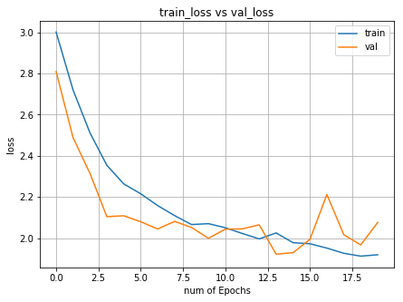

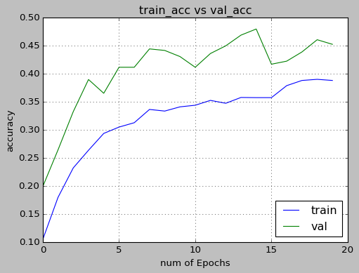

```python
# visualizing losses and accuracy
%matplotlib inline
train_loss=hist.history['loss']
val_loss=hist.history['val_loss']
train_acc=hist.history['acc']
val_acc=hist.history['val_acc']
xc=range(num_epoch)

plt.figure(1,figsize=(7,5))
plt.plot(xc,train_loss)
plt.plot(xc,val_loss)
plt.xlabel('num of Epochs')
plt.ylabel('loss')
plt.title('train_loss vs val_loss')
plt.grid(True)
plt.legend(['train','val'])
#print plt.style.available # use bmh, classic,ggplot for big pictures
plt.style.use(['classic'])

plt.figure(2,figsize=(7,5))
plt.plot(xc,train_acc)
plt.plot(xc,val_acc)
plt.xlabel('num of Epochs')
plt.ylabel('accuracy')
plt.title('train_acc vs val_acc')
plt.grid(True)
plt.legend(['train','val'],loc=4)
#print plt.style.available # use bmh, classic,ggplot for big pictures
plt.style.use(['classic'])
```

```python
# Training with callbacks
from keras import callbacks

filename='model_train_new.csv'
csv_log=callbacks.CSVLogger(filename, separator=',', append=False)

early_stopping=callbacks.EarlyStopping(monitor='val_loss', min_delta=0, patience=0, verbose=0, mode='min')

filepath="Best-weights-my_model-{epoch:03d}-{loss:.4f}-{acc:.4f}.hdf5"

checkpoint = callbacks.ModelCheckpoint(filepath, monitor='val_loss', verbose=1, save_best_only=True, mode='min')

callbacks_list = [csv_log,early_stopping,checkpoint]

hist = model.fit(X_train, y_train, batch_size=16, nb_epoch=num_epoch, verbose=1, validation_data=(X_test, y_test),callbacks=callbacks_list)
```

```
Train on 3467 samples, validate on 367 samples
```

```python
# Evaluating the model

score = model.evaluate(X_test, y_test,
                       #show_accuracy=True,
                       verbose=0)
print('Test Loss:', score[0])
print('Test accuracy:', score[1])

test_image = X_test[0:1]
print (test_image.shape)

print(model.predict(test_image))
print(model.predict_classes(test_image))
print(y_test[0:1])
```

```
('Test Loss:', 2.0730057094012686)
('Test accuracy:', 0.43324250721801527)
(1, 128, 128, 1)
[[ 0.03264538  0.00836913  0.15534531  0.03582368  0.09648614  0.0070323
   0.00728294  0.02037043  0.00141774  0.02418616  0.02014648  0.03297699
   0.15133618  0.01000428  0.02887587  0.1706166   0.03214488  0.02341671
   0.08073618  0.03263618  0.02815048]]
[15]
[[ 0.  0.  0.  0.  0.  0.  0.  0.  0.  0.  0.  0.  0.  0.  0.  1.  0.  0.
   0.  0.  0.]]
```

```python
#Loading the test data(New Images)
test_path=PATH + '/data/test'
print(test_path)
from glob import glob
new_images=[]
test_data_list=[]
for fn in glob('data/test/*.jpg'):
    new_images.append(fn[10:])
    input_img = cv2.imread(fn)
    input_img=cv2.cvtColor(input_img, cv2.COLOR_BGR2GRAY)
    input_img_resize=cv2.resize(input_img,(128,128))
    test_data_list.append(input_img_resize)

test_data = np.array(test_data_list)
test_data = test_data.astype('float32')
test_data /= 255
print (test_data.shape)

#Reshaping for channel = 1, if we read the data as colour(RGB) image shape will be in desired format
test_data= np.expand_dims(test_data, axis=3)
print (test_data.shape)

# Predicting the test image
print(model.predict(test_data))
print(model.predict_classes(test_data))
result=(model.predict_classes(test_data))
print(type(result))
```

[output not shown]

```python
#Writing the output to csv file
print result.shape
testdata=np.array(new_images)
print (testdata.shape)
import pandas as pd

predictions = pd.DataFrame(data=np.column_stack((testdata,result)),columns=['img','class'],)
predictions.sort_values(['class'], ascending=True)
predictions.head()

predictions.to_csv('predictions.csv', sep=',', index=False)
```

```
(388,)
(388,)
```

```
(1, 1, 126, 126, 32)
(126, 126, 32)
(126, 126, 32)
```

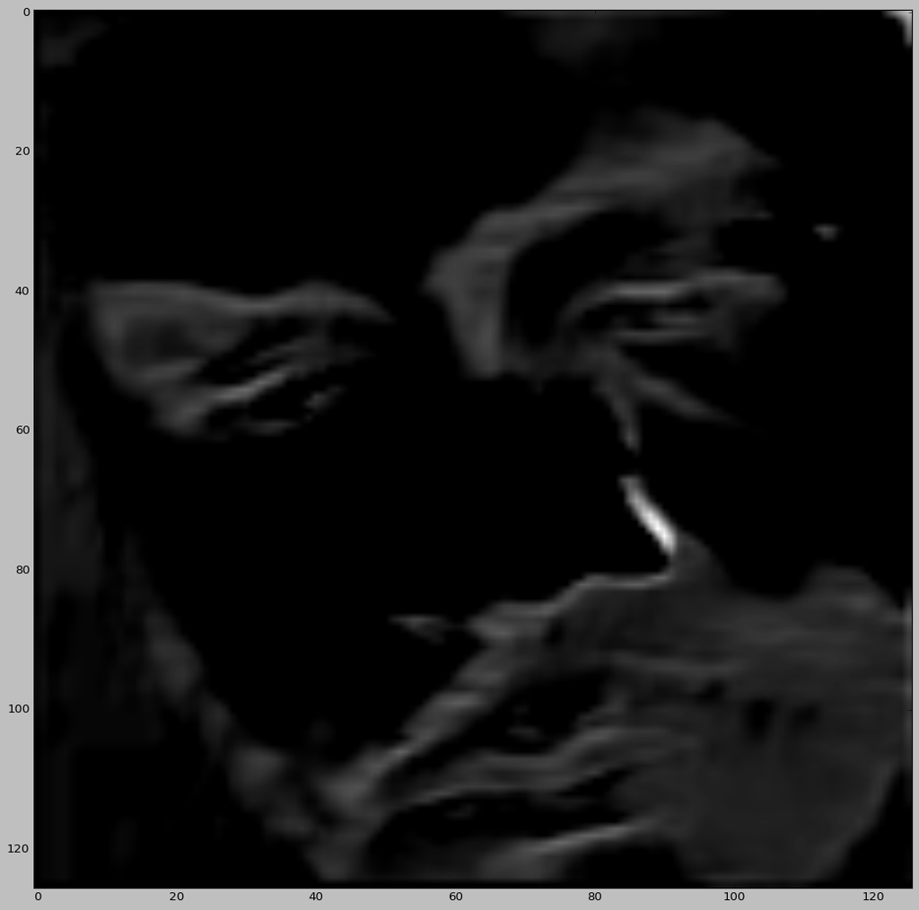

```python
#stacked n/w,only imp features will stay in Relu
# Visualizing the intermediate layer
def get_featuremaps(model, layer_idx, X_batch):
	get_activations = K.function([model.layers[0].input, K.learning_phase()],[model.layers[layer_idx].output,])
	activations = get_activations([X_batch,0])
	return activations

layer_num=3
filter_num=0

activations = get_featuremaps(model, int(layer_num),test_image)

print (np.shape(activations)) #(1, 1, 126, 126, 32)
feature_maps = activations[0][0]
print (np.shape(feature_maps)) # (126, 126, 32)

print (feature_maps.shape)

fig=plt.figure(figsize=(16,16))
plt.imshow(feature_maps[:,:,filter_num],cmap='gray')
plt.savefig("featuremaps-layer-{}".format(layer_num) + "-filternum-{}".format(filter_num)+'.jpg')
```

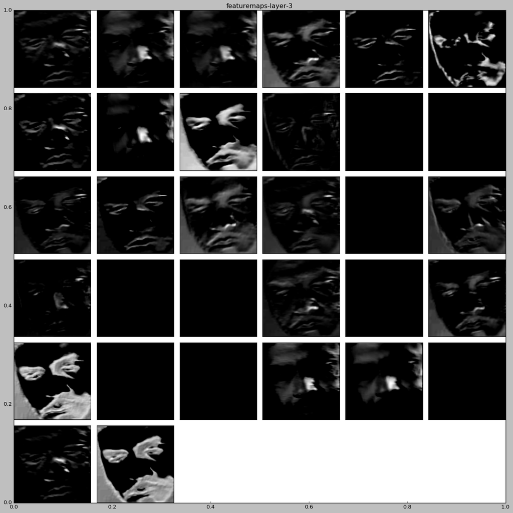

```python
#plot for all layers
num_of_featuremaps=feature_maps.shape[2]
fig=plt.figure(figsize=(16,16))
plt.title("featuremaps-layer-{}".format(layer_num))
subplot_num=int(np.ceil(np.sqrt(num_of_featuremaps)))
for i in range(int(num_of_featuremaps)):
	ax = fig.add_subplot(subplot_num, subplot_num, i+1)
	#ax.imshow(output_image[0,:,:,i],interpolation='nearest' ) #to see the first filter
	ax.imshow(feature_maps[:,:,i],cmap='gray')
	plt.xticks([])
	plt.yticks([])
	plt.tight_layout()
plt.show()
fig.savefig("featuremaps-layer-{}".format(layer_num) + '.jpg')
```

```python
# load json and create model# Printing the confusion matrix
from sklearn.metrics import classification_report,confusion_matrix
import itertools

Y_pred = model.predict(X_test)
print(Y_pred)
y_pred = np.argmax(Y_pred, axis=1) # to get the maximum value as o/p is onehot encoded
print(y_pred)
#y_pred = model.predict_classes(X_test)
#print(y_pred)
target_names = ['class 0(Ambareesh)', 'class 1(AnilKapoor)', 'class 2(BhanuPriya)','class 3(CochinHaneefa)',
               'class 0(Jagathy)', 'class 1(JosePrakash)', 'class 2(Kajal)','class 3(Kavya)',
               'class 0(Kochinhaneefa)', 'class 1(KotaSrinivasaRao)', 'class 2(MallikarjunRao)','class 3(Rajkumar)',
               'class 0(RamaPrabha)', 'class 1(RimiSen)', 'class 2(RishiKapoor)','class 3(SailenMukherjee)',
               'class 0(ShivaRam)', 'class 1(SureshGopi)', 'class 2(Trisha)','class 3(Vajramuni)',
               'class 0(Vishnuvardhan)']

print(classification_report(np.argmax(y_test,axis=1), y_pred,target_names=target_names))

print(confusion_matrix(np.argmax(y_test,axis=1), y_pred))
```

```
[[  2.75842285e-05   3.58159021e-02   1.25759433e-03 ...,   4.20964621e-02
    2.01592484e-04   7.63677817e-04]
 [  1.29108329e-03   2.69004822e-01   2.11315622e-04 ...,   6.50763437e-02
    6.30653137e-03   2.71433387e-02]
 [  2.50098836e-02   1.35577902e-01   1.32281156e-02 ...,   5.92951588e-02
    3.78755555e-02   9.28862244e-02]
 ...,
 [  8.99429470e-02   1.27792610e-02   9.15228426e-02 ...,   7.38232285e-02
    7.51530156e-02   5.06320745e-02]
 [  2.62157440e-01   3.37268598e-03   1.72094889e-02 ...,   2.38185376e-02
    4.21270877e-02   4.34437506e-02]
 [  4.83976630e-03   1.53351957e-02   2.46335985e-04 ...,   1.33203678e-02
    1.30912066e-02   3.23453657e-02]]
[15  1 17 17 11 12 18  0  1 16 18  7 11 11  7  0 10 17 15  6  1 17  9 11  9
  9 11  9 11 18 14  9 11 11 11  7 10 12 12  9 11 10 11 11 11  9 18 15  0  9
 11  7 13 11 11  9 11 12  6 12 12 18 14 11 13 10 18 18  9  3 17 11 17 10 10
  9  0 18  6  4 13 10  0  3 18 18 13 15 18 12 18 18 17 11 11  6 11  6 15 18
 14  0  3 13 19 12 11 17 12  9 11 13  0 11  6 18  4 15  4  0 13 11 14 12  9
  9 12  9 17 12 14 10 18 15  0 18  0 18 12  9 18 13 11 11 11  9 17  9 11 18
 12 12 11 11 13 11  0 15 11  9  3  6  9  9 15 16 18  9 11 12  6  7 11  6 13
 12  0 12 12 11  9 14 13 14 13 11 18 11 12 11  9 12  6 11 11 11  6  3 12 17
 11 15 17 16 11  0 12 18 12  9  4  4 10 17 18 11 17  6 10 15 18  9 11 14 11
  3  6 18 17 13  9 11 18 15 13 11 15  6 12 13  3  2 16 17  0  4 11 15 13  5
 13 17 15 18  6 18 11 11  0 12 18 16 12 12  2  6 17 11 18 18 11 11  1  9 18
 11 11  9  6 17  9  9 15 11 12 12 17  9 12  2 13 11 12 13 18  1  5 17 17  3
  5 16 11  2 11 17 11 18 11 16  9 18 17 18 11  0 12  6 13 15 11  0 18 18 11
 17  7 10 18 11  5 13 12 12 17 11 11 18 13 14  9 12 12 18 16  6 11 12 18  9
  7 12 12 17 18  0 18  6 10 18 18  4  9 17  4  0  9]
                           precision    recall  f1-score   support

       class 0(Ambareesh)       0.26      0.25      0.26        20
      class 1(AnilKapoor)       0.80      0.33      0.47        12
      class 2(BhanuPriya)       0.25      0.05      0.08        20
   class 3(CochinHaneefa)       0.00      0.00      0.00        15
         class 0(Jagathy)       0.38      0.27      0.32        11
     class 1(JosePrakash)       1.00      0.36      0.53        11
           class 2(Kajal)       0.65      0.50      0.57        26
           class 3(Kavya)       0.71      0.25      0.37        20
   class 0(Kochinhaneefa)       0.00      0.00      0.00         4
class 1(KotaSrinivasaRao)       0.43      0.76      0.55        21
```

[output cut: 20 more lines]

```
 [ 0  0  0  0  0  0 13  1  0  0  0  0  0  4  1  0  0  0  7  0  0]
 [ 1  0  0  0  0  0  0  5  0  1  0  1  6  1  1  0  1  0  3  0  0]
 [ 0  0  0  0  0  0  0  0  0  0  0  2  1  0  0  0  0  1  0  0  0]
 [ 0  0  0  1  1  0  0  0  0 16  0  1  0  0  0  0  0  2  0  0  0]
 [ 0  0  1  1  0  0  0  0  0  1  6  1  2  0  0  0  0  0  1  0  0]
 [ 1  0  0  1  0  0  0  0  0  1  0 24  0  0  0  0  0  0  0  0  0]
 [ 3  0  0  0  0  0  0  0  0  1  0  0 14  0  0  0  0  2  2  0  0]
 [ 0  0  0  0  0  0  1  0  0  0  0  0  2 12  0  0  0  0  1  0  0]
 [ 0  0  0  0  0  0  5  0  0  0  0  2  1  2  7  1  3  0  6  0  0]
 [ 0  0  0  0  0  0  0  0  0  0  0  0  0  0  0 15  0  0  1  0  0]
 [ 2  0  0  0  0  0  0  0  0  2  0  5  2  0  0  0  2  2  1  0  0]
 [ 0  0  0  0  0  0  0  0  0  6  2  2  1  0  0  0  0 11  0  1  0]
 [ 2  0  1  1  0  0  1  0  0  1  1  2  1  2  0  0  0  0 12  0  0]
 [ 0  0  0  0  1  0  0  0  0  1  0  5  0  0  0  0  0  1  0  0  0]
 [ 0  0  0  0  0  0  0  0  0  1  1  5  0  0  0  1  2  3  2  0  0]]
```

```
Confusion matrix, without normalization
[[ 5  0  1  4  0  0  0  0  0  2  0  8  0  0  0  0  0  0  0  0  0]
 [ 0  4  0  0  0  0  0  0  0  0  1  1  1  1  0  0  0  3  1  0  0]
 [ 2  0  1  0  2  0  0  0  0  1  1  1  5  0  0  0  0  0  7  0  0]
 [ 0  1  0  0  1  0  0  0  0  1  0  7  3  0  0  0  0  1  1  0  0]
 [ 3  0  0  0  3  0  0  0  0  1  0  2  0  0  0  0  0  1  1  0  0]
 [ 0  0  0  0  0  4  0  1  0  1  0  2  1  0  0  0  0  1  1  0  0]
 [ 0  0  0  0  0  0 13  1  0  0  0  0  0  4  1  0  0  0  7  0  0]
 [ 1  0  0  0  0  0  0  5  0  1  0  1  6  1  1  0  1  0  3  0  0]
 [ 0  0  0  0  0  0  0  0  0  0  0  2  1  0  0  0  0  1  0  0  0]
 [ 0  0  0  1  1  0  0  0  0 16  0  1  0  0  0  0  0  2  0  0  0]
 [ 0  0  1  1  0  0  0  0  0  1  6  1  2  0  0  0  0  0  1  0  0]
 [ 1  0  0  1  0  0  0  0  0  1  0 24  0  0  0  0  0  0  0  0  0]
 [ 3  0  0  0  0  0  0  0  0  1  0  0 14  0  0  0  0  2  2  0  0]
 [ 0  0  0  0  0  0  1  0  0  0  0  0  2 12  0  0  0  0  1  0  0]
 [ 0  0  0  0  0  0  5  0  0  0  0  2  1  2  7  1  3  0  6  0  0]
 [ 0  0  0  0  0  0  0  0  0  0  0  0  0  0  0 15  0  0  1  0  0]
 [ 2  0  0  0  0  0  0  0  0  2  0  5  2  0  0  0  2  2  1  0  0]
 [ 0  0  0  0  0  0  0  0  0  6  2  2  1  0  0  0  0 11  0  1  0]
 [ 2  0  1  1  0  0  1  0  0  1  1  2  1  2  0  0  0  0 12  0  0]
 [ 0  0  0  0  1  0  0  0  0  1  0  5  0  0  0  0  0  1  0  0  0]
 [ 0  0  0  0  0  0  0  0  0  1  1  5  0  0  0  1  2  3  2  0  0]]
```

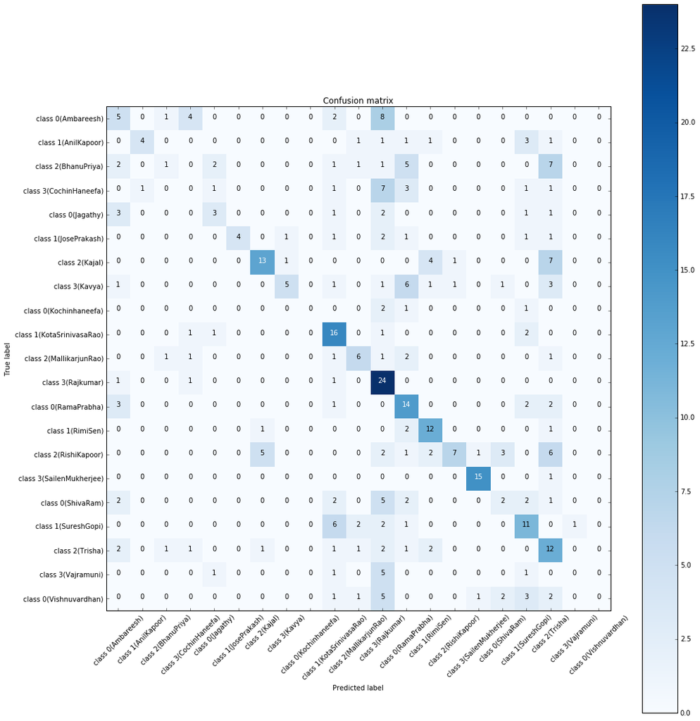

```python
#Plotting Confusion matrix
# Plotting the confusion matrix
%matplotlib inline
def plot_confusion_matrix(cm, classes,
                          normalize=False,
                          title='Confusion matrix',
                          cmap=plt.cm.Blues):
    """
    This function prints and plots the confusion matrix.
    Normalization can be applied by setting `normalize=True`.
    """
    plt.imshow(cm, interpolation='nearest', cmap=cmap)
    plt.title(title)
    plt.colorbar()
    tick_marks = np.arange(len(classes))
    plt.xticks(tick_marks, classes, rotation=45)
    plt.yticks(tick_marks, classes)

    if normalize:
        cm = cm.astype('float') / cm.sum(axis=1)[:, np.newaxis]
        print("Normalized confusion matrix")
    else:
        print('Confusion matrix, without normalization')

    print(cm)

    thresh = cm.max() / 2.
    for i, j in itertools.product(range(cm.shape[0]), range(cm.shape[1])):
        plt.text(j, i, cm[i, j],
                 horizontalalignment="center",
                 color="white" if cm[i, j] > thresh else "black")

    plt.tight_layout()
    plt.ylabel('True label')
    plt.xlabel('Predicted label')
# Compute confusion matrix
cnf_matrix = (confusion_matrix(np.argmax(y_test,axis=1), y_pred))

np.set_printoptions(precision=2)

plt.figure(figsize=(15,15))

# Plot non-normalized confusion matrix
plot_confusion_matrix(cnf_matrix, classes=target_names,
                      title='Confusion matrix')
#plt.show()
```

```python
# Saving and loading model and weights
from keras.models import model_from_json
from keras.models import load_model

# serialize model to JSON
model_json = model.to_json()
with open("model.json", "w") as json_file:
    json_file.write(model_json)
# serialize weights to HDF5
model.save_weights("model.h5")
print("Saved model to disk")

# load json and create model
json_file = open('model.json', 'r')
loaded_model_json = json_file.read()
json_file.close()
loaded_model = model_from_json(loaded_model_json)
# load weights into new model
loaded_model.load_weights("model.h5")
print("Loaded model from disk")

model.save('model.hdf5')
loaded_model=load_model('model.hdf5')
```

```
Saved model to disk
Loaded model from disk
```